# College Outcomes Analysis

Data Munging & EDA

Stephanie Rivera, Xiaotai Chai, Fanny Chow, Richard Decal

October 26, 2017

# I. Introduction

With over 7,000 institutions in the United States, students consider many factors when deciding where to attend college. The College Scorecard aims to help students, parents, and counselors make an informed choice on college choice.

# II. Data

Website: https://collegescorecard.ed.gov/  
Dataset: https://collegescorecard.ed.gov/data/  
Documentation: https://collegescorecard.ed.gov/data/documentation/

# III. Reading in the Data in Language-Native Format

### Load libraries

```r
library(tidyverse)
library(purrr)
library(data.table)
```

### Set working directory

```r
# double check that this puts you in the right dir
project.dir <- getwd()
setwd(project.dir)
dataset.dir <- "Data"
outputs.dir <- "Output"
```

### Generate a list of files to be read in

```r
file_names <- list.files(file.path(project.dir, dataset.dir), pattern="*.csv", full.names=TRUE)
```

### Create function for reading in filename string

We extract the year from the filename. For example: from the filename “MERGED2007_01_PP.csv,” we obtained the year from 13 characters from the end of the string.

```r
extract_yr_from_fname <- function(fname) {
  l <- nchar(fname)
  start <- l-13
  end <- l-10
  year <- substr(fname, start, end)
  return(year)
}
file_years <- lapply(file_names, extract_yr_from_fname)
```

### Read in files and combine

We use the `fread` function from the `data.table` package to read in a list of files and their corresponding filenames. We coerce missing data values that are “NULL” or empty strings “” into NA’s.

```r
fname_to_dtable <- function(filename){
    x <- fread(filename, skip=0, na.strings = c("NULL", ""))

    # append col called filename to x
      x <- mutate(x, Year=extract_yr_from_fname(filename))
      return(x)
}
```

# IV. Assessing the Quality of the Data

## Measuring completeness of each year

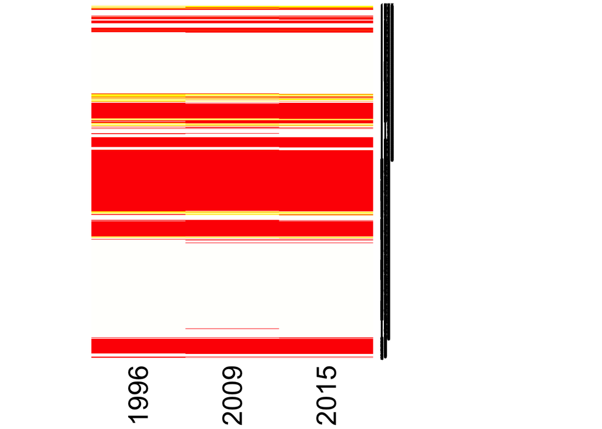

```r
data_1996 <- fname_to_dtable(file_names[1])

data2009 <- fname_to_dtable(file_names[13])

data2015 <- fname_to_dtable(file_names[20])

ratio_missing <- function(frame){
  ratiomissing <- c()
  for (i in 1:ncol(frame)){

  ratiomissing[i] <- sum(is.na(frame[,i]))/length(frame[,i])

  }
  return(ratiomissing)
}

ratio_1996 <- (ratio_missing(data_1996))
ratio_2009 <- (ratio_missing(data2009))
ratio_2015 <- (ratio_missing(data2015))

B <- matrix(c(ratio_1996,ratio_2009,ratio_2015), nrow=3,ncol=1777)
B1 <- t(B)
colnames(B1) <- c("1996","2009","2015")
dater <- data.matrix(B1)
collegedata_heatmap <- heatmap(dater, Rowv=NA, Colv=NA, col = heat.colors(256), scale="column", margins=c(5,10))
```

With the use of this heatmap, we determined that many of the files could be missing large portions of data. This heatmap helped us move forward with another tool to summarize the completeness of the data in order to determine which file to use for our analysis.

We wrote a function that calculates the proportion of columns out of every colummn in the file that satisfies the condition of having at most 20% missing data per column. For example, if a file has 10 columns, and 4 columns have more than 20% missing data, the ratio of good columns over all columns is 6/10.

```r
calc_perc_goodcols_in_table <- function(dtable){
    na.max <- .2
    na.prop <- apply(dtable, 2, function(x) sum(is.na(x)/length(x)))
    percent_good <- (sum(na.prop < na.max)/length(dtable))
    return(percent_good)
}

score_fname_list <- function(fname_list){
    scores <- c()
    for (i in 1:length(fname_list)){
        f <- fname_list[i]
        tab <- fname_to_dtable(f)
        score <- calc_perc_goodcols_in_table(tab)
        cat("\n yr", extract_yr_from_fname(f), "score", score)
        scores[i] <- score
  }
  return(scores)
}

file_scores <- score_fname_list(fname_list = file_names)
```

```
 yr 1996 score 0.1445444
 yr 1997 score 0.1974128
 yr 1998 score 0.3031496
 yr 1999 score 0.420135
 yr 2000 score 0.5224972
 yr 2001 score 0.5309336
 yr 2002 score 0.6344207
 yr 2003 score 0.6563555
 yr 2004 score 0.7474691
 yr 2005 score 0.772216
 yr 2006 score 0.7508436
 yr 2007 score 0.795838
 yr 2008 score 0.7710911
 yr 2009 score 0.8250844
 yr 2010 score 0.7924634
 yr 2011 score 0.8397075
 yr 2012 score 0.8340832
 yr 2013 score 0.8492688
 yr 2014 score 0.803712
 yr 2015 score 0.2637795
```

```r
cat("the best year is", max(file_scores))
```

```
the best year is 0.8492688
```

The year 2013 is the best year in terms of % of total columns which have at most 20% NA values.

## Loading 2013 values to table

```r
d2013 <- fname_to_dtable(file_names[18])
```

## Calculating column-wise NA percent

```r
filter_NA_cols <- function(dtable){
    na.max <- .2
    na.prop <- apply(dtable, 2, function(x) sum(is.na(x)/length(x)))
    good_cols <- na.prop < na.max
    return(dtable[,good_cols])
}

d2013 <- filter_NA_cols(d2013)

(calc_perc_goodcols_in_table(d2013))
```

```
[1] 1
```

# V. Analyzing Variables of Interest

### Analyzing New College vs Other Schools

(see relationship.Rmd)